# Notas del Curso de Métodos Numéricos

Carlos E Martínez-Rodríguez

01 September, 2025

# Introducción al uso de R

## Sesión 1

### Operadores Lógicos

```r
17<5
```

```
## [1] FALSE
```

```r
17>5
```

```
## [1] TRUE
```

```r
17<=5
```

```
## [1] FALSE
```

```r
17>=5
```

```
## [1] TRUE
```

```r
17!=5
```

```
## [1] TRUE
```

```r
17==5
```

```
## [1] FALSE
```

## Operadores Aritméticos

```r
17+5
```

```
## [1] 22
```

```r
17*5
```

```
## [1] 85
```

```r
17*5
```

```
## [1] 85
```

```r
17^5
```

```
## [1] 1419857
```

```r
17%/%5
```

```
## [1] 3
```

```r
17%%5
```

```
## [1] 2
```

### Logaritmos y exponenciales

```r
log(1)
```

```
## [1] 0
```

```r
log(12)
```

```
## [1] 2.484907
```

```r
log(12,2)
```

```
## [1] 3.584963
```

```r
exp(12)
```

```
## [1] 162754.8
```

```r
exp(1)
```

```
## [1] 2.718282
```

### Funciones Trigonométicas

```r
sin(45)
```

```
## [1] 0.8509035
```

```r
cos(45)
```

```
## [1] 0.525322
```

```r
tan(45)
```

```
## [1] 1.619775
```

```r
asin(0.96)
```

```
## [1] 1.287002
```

```r
acos(0.97)
```

```
## [1] 0.2455655
```

```r
atan(0.45)
```

```
## [1] 0.4228539
```

### Funciones varias

```r
abs(-34)
```

```
## [1] 34
```

```r
sqrt(8)
```

```
## [1] 2.828427
```

```r
floor(1.56)
```

```
## [1] 1
```

```r
ceiling(1.56)
```

```
## [1] 2
```

```r
max(4,7,2,12)
```

```
## [1] 12
```

```r
min(4,7,2,12)
```

```
## [1] 2
```

```r
sign(-45)
```

```
## [1] -1
```

### Ejercicios de práctica

1. calcular la expresion cos(pi/6+pi/2)+e^2 2 calcular la expresion cos(pi/6+pi/2)+e^2*log(5)+arc cos(1/raiz(2)) 3 introducir las siguientes expresiones:
1. 1/7
2. options(digits=3); 1/7
3. options(digits=6); 1/7
4. round(67.45)
5. round(75.324568,2)
6. options(digits=7);
7. signif(56.345458234234,2)
8. signif(56.345458234234)
9. exp(-30)
10. options(scipen= 999)
11. exp(-30)
12. options(scipen=0)

## Sesión 2

### Definición de constantes

```r
e = exp(1);
x = 0.0034
e <- exp(1)
x <- 0.034;
x0 = e^(2*x)
```

### Concatenar y pegar expresiones

```r
txt = "El valor de x0 es _"
cat(txt, x0)
```

```
## El valor de x0 es _ 1.070365
```

```r
paste(txt,x0)
```

```
## [1] "El valor de x0 es _ 1.07036530847877"
```

```r
paste0(txt,x0)
```

```
## [1] "El valor de x0 es _1.07036530847877"
```

### Asignación e impresión

```r
x0 <- 1
x1 <- x0 - pi*x0 + 1
(x1 <- x0 - pi*x0 + 1 )
```

```
## [1] -1.141593
```

```r
print(x1)
```

```
## [1] -1.141593
```

### Listado de objetos definidos

```r
ls()
```

```
## [1] "e"   "txt" "x"   "x0"  "x1"
```

Eliminar todos los objetos

```r
rm(list= ls())
ls()
```

```
## character(0)
```

### Imprimir pegar avanzado

```r
x0 <- 1
x1 <- x0 - pi*x0 + 1
cat("x0 =", x0, "\n","x1 =", x1)
```

```
## x0 = 1
##  x1 = -1.141593
```

## Sesión 3

### Definición de funciones

nombre_funcion <- function(param1,param2,param3,…,paramn){ instruccion 1 instruccion 2 return(valor_de_retorno) }

Ejemplo 1

```r
fun1 <- function(x,a,b,h,k){
  res <- a+b*cos(hx+k)
  return(res)
}
```

Ejemplo 2

```r
Discriminante <- function(a,b,c){
  res <- b^2-4*a*c
  return(res)
}
```

### Gráficas

```r
fun2 <- function(x,h,k){
  res <- 1/h*sin(k*x)
  return(res)
}
```

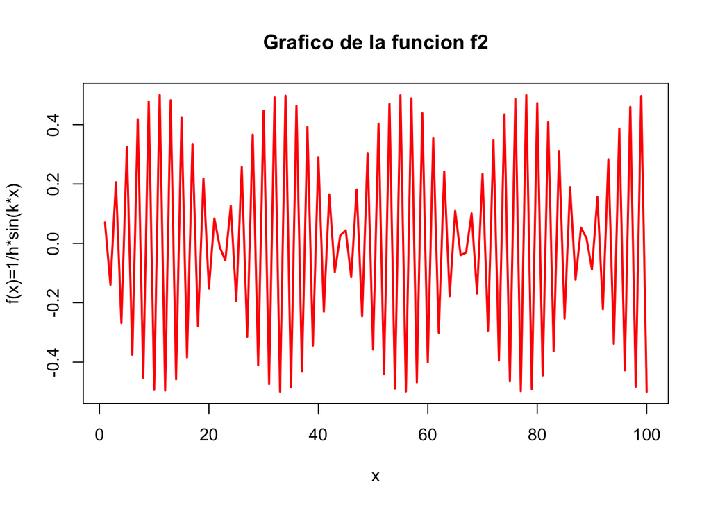

```r
f2 <- fun2(1:100,2,3)
plot(f2,type="l", col= "red", lwd=2,
     main= "Grafico de la funcion f2",
     xlab= "x",
     ylab="f(x)=1/h*sin(k*x)",
     axes= TRUE)
```

# Gráficas en R

Primero limpiamos nuestro ambiente, eliminamos variables y cerramos las gráficas generadas con anterioridad.

Generemos los datos correspondientes a los pesos registrados de 90 personas

```r
kgs <- c(100.5, 91.3, 60.4, 83.2, 49.6, 103.1, 60.3, 109.3, 83.5,
         63.9, 106, 50, 47, 89.7, 108.5, 78.9, 82.7, 60.7, 98.7, 85.2, 48.7, 106.7, 63.9, 84.1,
         69.5, 53.3, 108.9, 91.8, 108.6, 54.5, 95.1, 90.6, 115.9, 88.5, 67.7, 115.1, 108.3, 76.8,
         81.4, 102.6, 63.9, 105.9, 106.7, 76.3, 113.7, 50.3, 105.8, 81.4, 67.9, 91.3, 68.9, 93.9,
         113.7, 87.7, 92.8, 76.2, 104.7, 109.7, 72.6, 81.6, 112.2, 79.8, 60.7, 95.7, 100.1, 94,
         60.5, 117.1, 45.5, 112.7, 51.7, 107.8, 86.6, 90.3, 105.9, 64.7, 48, 55.4, 52.9, 58.2,
         117.1, 59.6, 69.9, 96.9, 97, 66.5, 67.4, 77.2, 73.7, 113)
```

## Procesamiento de datos

Primero obtenemos un resumen de los datos generados

```r
summary(kgs)
```

```
##    Min. 1st Qu.  Median    Mean 3rd Qu.    Max.
##   45.50   65.15   84.65   83.86  104.30  117.10
```

Ordenamos los datos

```r
kgs_ord <- sort(kgs)
cte <- 9
```

Definimos un vector que nos servirá para calcular los deciles:

```r
indices <- 1:10; (indices)
```

```
##  [1]  1  2  3  4  5  6  7  8  9 10
```

```r
t <- cte*indices; (t)
```

```
##  [1]  9 18 27 36 45 54 63 72 81 90
```

```r
mis_deciles <- kgs_ord[t]; (mis_deciles)
```

```
##  [1]  52.9  60.7  67.9  77.2  84.1  91.3  98.7 106.0 109.7 117.1
```

```r
cuantiles <- quantile(kgs); (cuantiles)
```

```
##     0%    25%    50%    75%   100%
##  45.50  65.15  84.65 104.30 117.10
```

```r
Q1 <- cuantiles[2]; (Q1)
```

```
##   25%
## 65.15
```

```r
Q2 <- cuantiles[3]; (Q2)
```

```
##   50%
## 84.65
```

```r
Q3 <- cuantiles[4]; (Q3)
```

```
##   75%
## 104.3
```

Calculemos la media, el valor máximo y el valor mínimo para los datos

```r
x_media <- mean(kgs)
mi_min <- min(kgs);
mi_max <- max(kgs);
```

## Gráficas con el comando *plot*

Generemos una gráfica simple de los datos

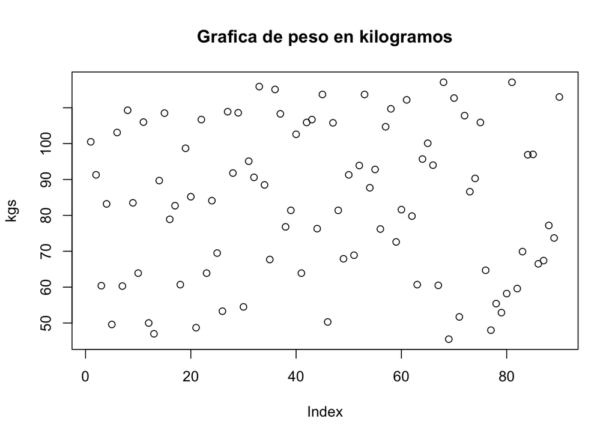

```r
plot(kgs,main="Grafica de peso en kilogramos")
```

Ahora agreguemos detalles, etiquetas, título, colores, etc a la misma gráfica

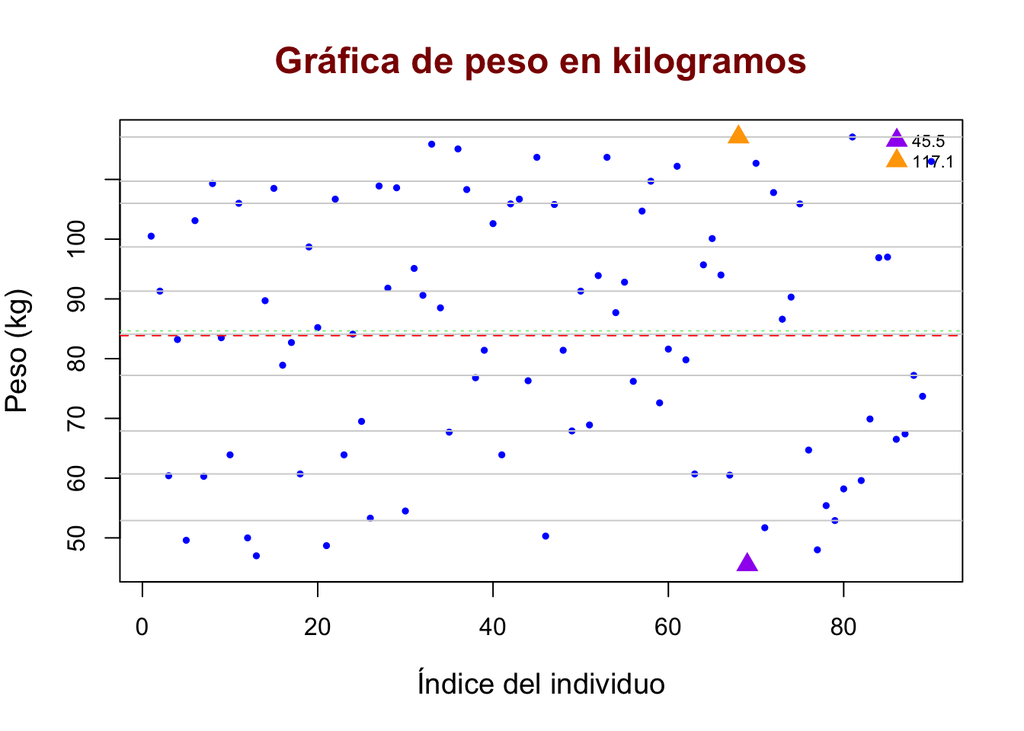

```r
plot(
  kgs,
  main = "Gráfica de peso en kilogramos",
  xlab = "Índice del individuo",
  ylab = "Peso (kg)",
  col = "blue",
  pch = 19,
  cex = 0.5,
  cex.main = 1.5,
  cex.lab = 1.2,
  col.main = "darkred")
legend(
  "topright",                  # ubicación
  legend = c(mi_min,mi_max),    # etiquetas
  pch = 17,
  col=c("purple","orange"),
  pt.cex = 1.5,                # tamaño de los símbolos
  cex = 0.7,
  bty = "n"                    # sin borde en la caja
)
abline(h = x_media, col = "red", lwd = 1, lty = 2)
abline(h = Q2, col = "lightgreen", lwd = 1, lty = 3)
abline(h = mis_deciles, col = "lightgray", lty = 1.5)
points(which.min(kgs), min(kgs), col = "purple", pch = 17, cex = 1.5)
points(which.max(kgs), max(kgs), col = "orange", pch = 17, cex = 1.5)
```

## Generación de *Histogramas*

Con la misma idea que la gráfica anterior, generemos un histograma de los mismos datos

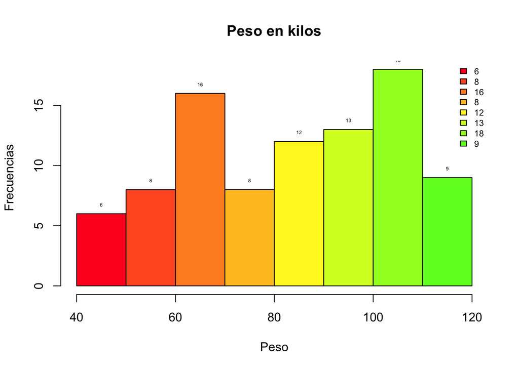

```r
nbreaks=10;
miscolores <- rainbow(25,0.85);
h <- hist(kgs, breaks = nbreaks, col= miscolores,
          main = 'Peso en kilos',
          xlab="Peso",
          ylab="Frecuencias")
text(h$mids, h$counts, labels = h$counts, pos = 3, cex = 0.4,
     col = "black")
nl <- length(h$counts);
legend(
  "topright",                  # ubicación
  legend = h$counts,    # etiquetas
  fill = miscolores,
  col = miscolores,    # colores (uno por cada símbolo)
  pt.cex = 1.5,                # tamaño de los símbolos
  cex = 0.7,
  bty = "n"                    # sin borde en la caja
)
```

Mejoremos el gráfico agregando detalles, leyendas e información en la parte lateral de la gráfica

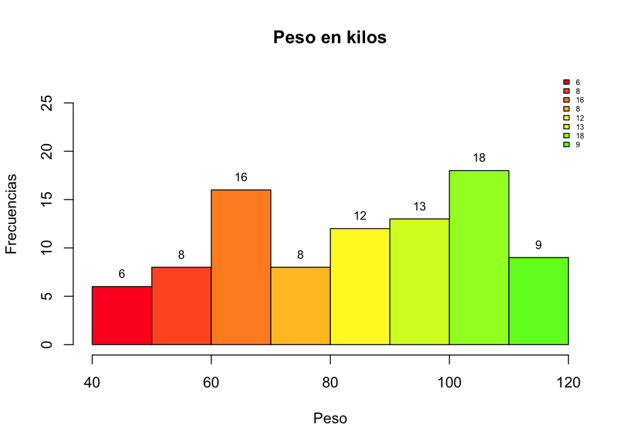

```r
##---- Mejora del grafico ----
h2 <- hist(kgs, breaks = nbreaks, col= miscolores,
          main = 'Peso en kilos',
          xlab="Peso",
          ylab="Frecuencias",
          ylim=c(0,max(h$counts)*1.5))
text(h$mids, h$counts, labels = h$counts, pos = 3, cex = 0.8,
     col = "black")
nl <- length(h$counts);
legend(
  "topright",                  # ubicación
  legend = h$counts,    # etiquetas
  fill = miscolores,
  col = miscolores,    # colores (uno por cada símbolo)
  pt.cex = 1.5,                # tamaño de los símbolos
  cex = 0.5,
  bty = "n"                    # sin borde en la caja
)
```

## Histograma con porcentajes

```r
##---- Grafico con porcentajes ----
h3 <- hist(kgs,
           breaks = nbreaks,
           col= miscolores,
           main = 'Peso en kilos',
           xlab="Peso",
           ylab="Porcentaje",
           ylim=c(0,max(h$density)*1.5),
           probability=TRUE)
porcentajes <- h3$counts/sum(h3$counts)*100

text(h3$mids,
     h3$density,
     labels = paste0(round(porcentajes,1),"%"),
     pos = 3,
     cex = 0.8,
     col = "black")

nl <- length(h3$counts); (nl)
```

```
## [1] 8
```

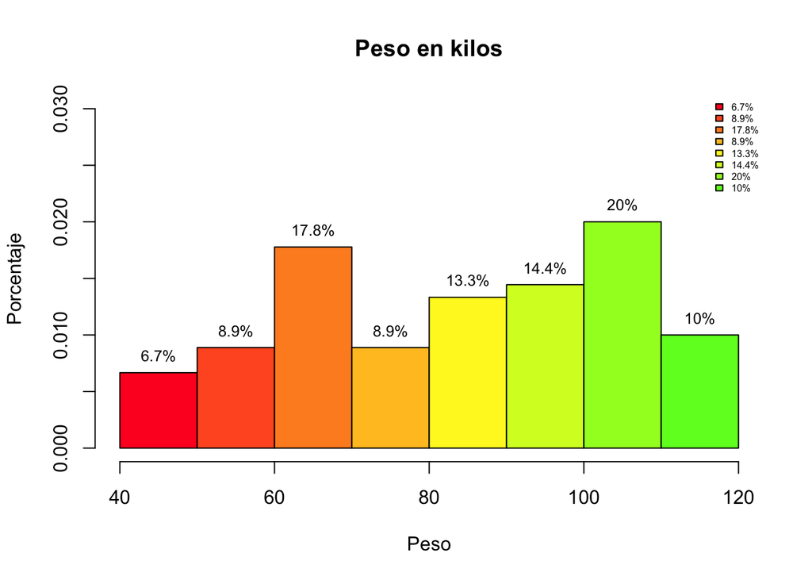

```r
legend(
  "topright",                  # ubicación
  legend = paste0(round(porcentajes,1),"%"),
  fill = miscolores,
  cex = 0.5,
  bty = "n"                    # sin borde en la caja
)
```

## Gráficos de pastel

```r
#---- Graficos de pastel ----
# Tus datos
nbreaks <- 10
intervalos <- cut(kgs, breaks = nbreaks); (intervalos)
```

```
##  [1] (95.6,103]  (88.5,95.6] (59.8,67]   (81.3,88.5] (45.4,52.7] (103,110]
##  [7] (59.8,67]   (103,110]   (81.3,88.5] (59.8,67]   (103,110]   (45.4,52.7]
## [13] (45.4,52.7] (88.5,95.6] (103,110]   (74.1,81.3] (81.3,88.5] (59.8,67]
## [19] (95.6,103]  (81.3,88.5] (45.4,52.7] (103,110]   (59.8,67]   (81.3,88.5]
## [25] (67,74.1]   (52.7,59.8] (103,110]   (88.5,95.6] (103,110]   (52.7,59.8]
## [31] (88.5,95.6] (88.5,95.6] (110,117]   (88.5,95.6] (67,74.1]   (110,117]
## [37] (103,110]   (74.1,81.3] (81.3,88.5] (95.6,103]  (59.8,67]   (103,110]
## [43] (103,110]   (74.1,81.3] (110,117]   (45.4,52.7] (103,110]   (81.3,88.5]
## [49] (67,74.1]   (88.5,95.6] (67,74.1]   (88.5,95.6] (110,117]   (81.3,88.5]
## [55] (88.5,95.6] (74.1,81.3] (103,110]   (103,110]   (67,74.1]   (81.3,88.5]
## [61] (110,117]   (74.1,81.3] (59.8,67]   (95.6,103]  (95.6,103]  (88.5,95.6]
## [67] (59.8,67]   (110,117]   (45.4,52.7] (110,117]   (45.4,52.7] (103,110]
## [73] (81.3,88.5] (88.5,95.6] (103,110]   (59.8,67]   (45.4,52.7] (52.7,59.8]
## [79] (52.7,59.8] (52.7,59.8] (110,117]   (52.7,59.8] (67,74.1]   (95.6,103]
## [85] (95.6,103]  (59.8,67]   (67,74.1]   (74.1,81.3] (67,74.1]   (110,117]
## 10 Levels: (45.4,52.7] (52.7,59.8] (59.8,67] (67,74.1] ... (110,117]
```

```r
tabla <- table(intervalos); (tabla)
```

```
## intervalos
## (45.4,52.7] (52.7,59.8]   (59.8,67]   (67,74.1] (74.1,81.3] (81.3,88.5]
##           8           6          10           8           6          10
## (88.5,95.6]  (95.6,103]   (103,110]   (110,117]
##          11           7          15           9
```

```r
porcentajes <- round(prop.table(tabla) * 100, 1); (porcentajes)
```

```
## intervalos
## (45.4,52.7] (52.7,59.8]   (59.8,67]   (67,74.1] (74.1,81.3] (81.3,88.5]
##         8.9         6.7        11.1         8.9         6.7        11.1
## (88.5,95.6]  (95.6,103]   (103,110]   (110,117]
##        12.2         7.8        16.7        10.0
```

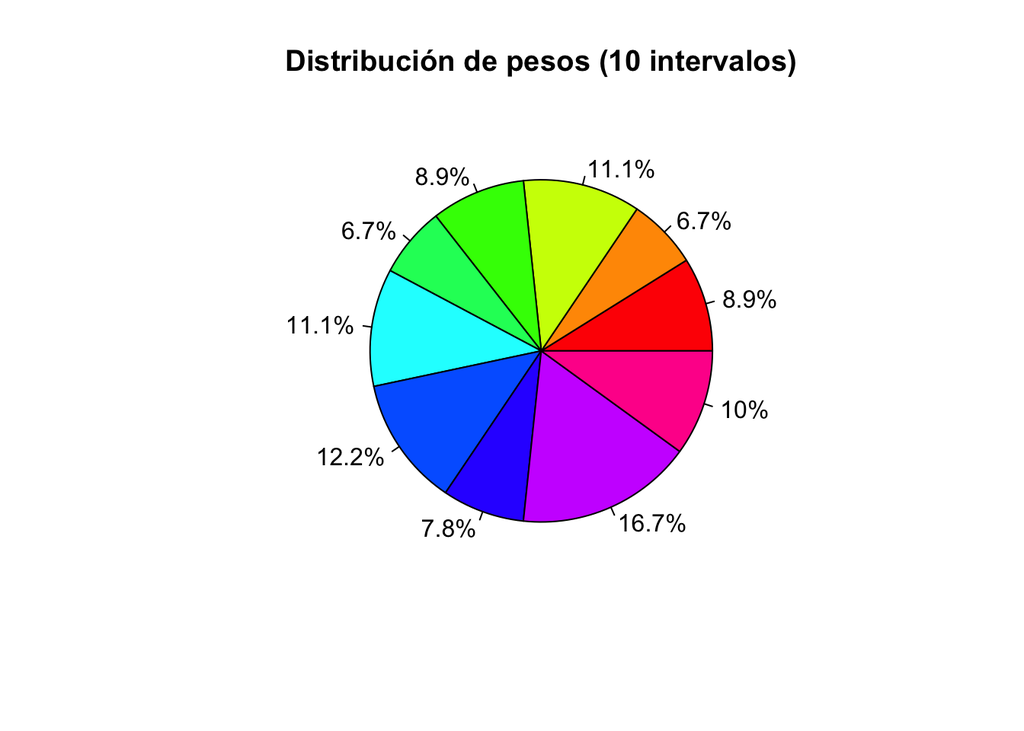

```r
pie(tabla,
    main = "Distribución de pesos (10 intervalos)",
    col = rainbow(length(tabla)),
    labels = paste0(porcentajes, "%"))
```

## Gráfica de Ojiva

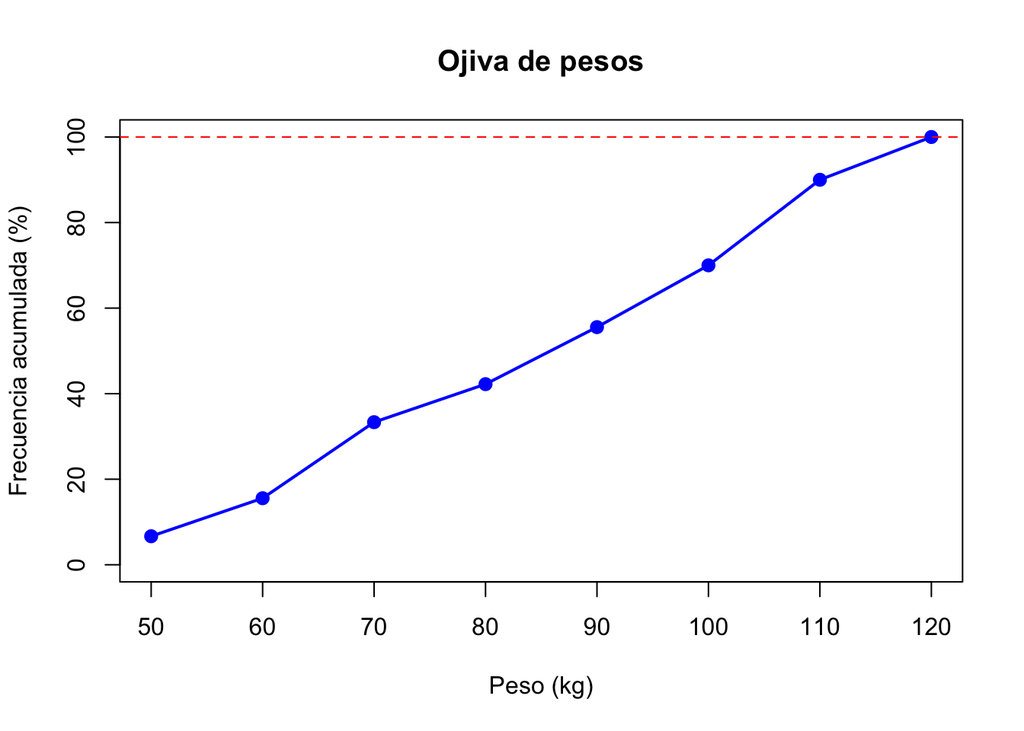

```r
#---- Grafica de Ojiva ----
##---- Grafica sencilla ----
nbreaks <- 10
h <- hist(kgs, breaks = nbreaks, plot = FALSE)
freq_acum <- cumsum(h$counts) / sum(h$counts) * 100
x_vals <- h$breaks[-1]
plot(x_vals, freq_acum, type = "o",
     main = "Ojiva de pesos",
     xlab = "Peso (kg)",
     ylab = "Frecuencia acumulada (%)",
     col = "blue", pch = 19, lwd = 2,
     ylim = c(0, 100))
abline(h = 100, col = "red", lty = 2)
```

Mejoramos la gráfica anterior.

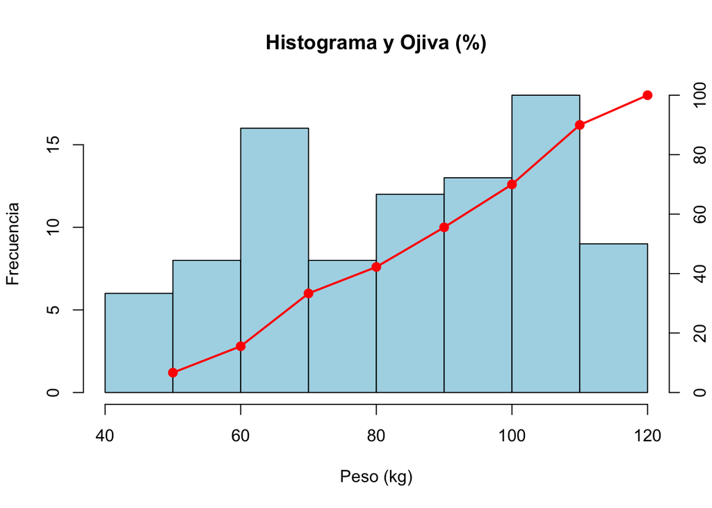

```r
##---- Grafica combinada ----
nbreaks <- 10
h <- hist(kgs, breaks = nbreaks, plot = FALSE)
hist(kgs,
     breaks = nbreaks,
     col = "lightblue",
     main = "Histograma y Ojiva (%)",
     xlab = "Peso (kg)",
     ylab = "Frecuencia")
freq_acum_pct <- cumsum(h$counts) / sum(h$counts) * 100
x_vals <- h$breaks[-1]
par(new = TRUE)
plot(x_vals, freq_acum_pct,
     type = "o", pch = 19, lwd = 2, col = "red",
     axes = FALSE, xlab = "", ylab = "",
     xlim = range(h$breaks), ylim = c(0, 100))
axis(4)                           # eje derecho
```

```r
#---- Fin ----
```

# Ejercicio de clase

Generemos los datos correspondientes a la estatura registrada de 100 personas

```r
estatura <- c(1.57, 1.97, 1.85, 1.78, 1.62, 1.67, 1.92, 1.96, 1.76,
1.94, 1.85, 1.71, 1.65, 1.98, 1.56, 1.84, 1.91, 1.61, 1.8, 1.58, 1.7, 1.62,
1.76, 1.84, 1.95, 1.67, 1.62, 1.65, 1.61, 1.56, 1.63, 1.96, 1.53, 1.75, 1.9,
1.92, 1.79, 1.62, 1.79, 1.57, 1.74, 1.55, 1.65, 1.84, 1.6, 1.7, 1.9, 1.61,
1.54, 1.89, 1.84, 1.76, 1.61, 1.59, 1.81, 1.52, 1.61, 1.91, 1.65, 1.51,
1.98, 1.54, 1.87, 1.92, 1.51, 1.93, 1.78, 1.67, 1.66, 1.82, 1.56, 1.66,
1.79, 1.88, 1.78, 1.84, 1.69, 1.95, 1.99, 1.88, 1.51, 1.76, 1.9, 1.6, 1.69,
1.77, 1.87, 1.67, 1.66, 1.71, 1.64, 1.81, 1.52, 1.8, 1.71, 1.52, 2, 1.81,
1.92, 1.7)
(estatura)
```

```
##   [1] 1.57 1.97 1.85 1.78 1.62 1.67 1.92 1.96 1.76 1.94 1.85 1.71 1.65 1.98 1.56
##  [16] 1.84 1.91 1.61 1.80 1.58 1.70 1.62 1.76 1.84 1.95 1.67 1.62 1.65 1.61 1.56
##  [31] 1.63 1.96 1.53 1.75 1.90 1.92 1.79 1.62 1.79 1.57 1.74 1.55 1.65 1.84 1.60
##  [46] 1.70 1.90 1.61 1.54 1.89 1.84 1.76 1.61 1.59 1.81 1.52 1.61 1.91 1.65 1.51
##  [61] 1.98 1.54 1.87 1.92 1.51 1.93 1.78 1.67 1.66 1.82 1.56 1.66 1.79 1.88 1.78
##  [76] 1.84 1.69 1.95 1.99 1.88 1.51 1.76 1.90 1.60 1.69 1.77 1.87 1.67 1.66 1.71
##  [91] 1.64 1.81 1.52 1.80 1.71 1.52 2.00 1.81 1.92 1.70
```

Calculemos la media, el valor máximo y el valor mínimo para los datos, así como la varianza y la desviación estándar

```r
x_media <- mean(estatura); (x_media)
```

```
## [1] 1.7407
```

```r
mi_min <- min(estatura); (mi_min)
```

```
## [1] 1.51
```

```r
mi_max <- max(estatura); (mi_max)
```

```
## [1] 2
```

```r
varianza <- var(estatura); (varianza)
```

```
## [1] 0.02010759
```

```r
DesvEst <- sd(estatura); (DesvEst)
```

```
## [1] 0.1418012
```

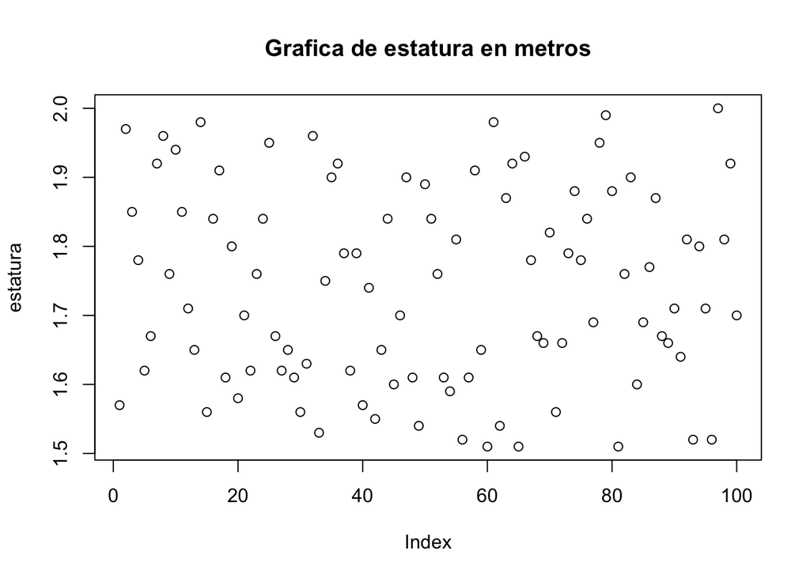

```r
plot(estatura,main="Grafica de estatura en metros")
```

Ahora agreguemos detalles, etiquetas, título, colores, etc a la misma gráfica

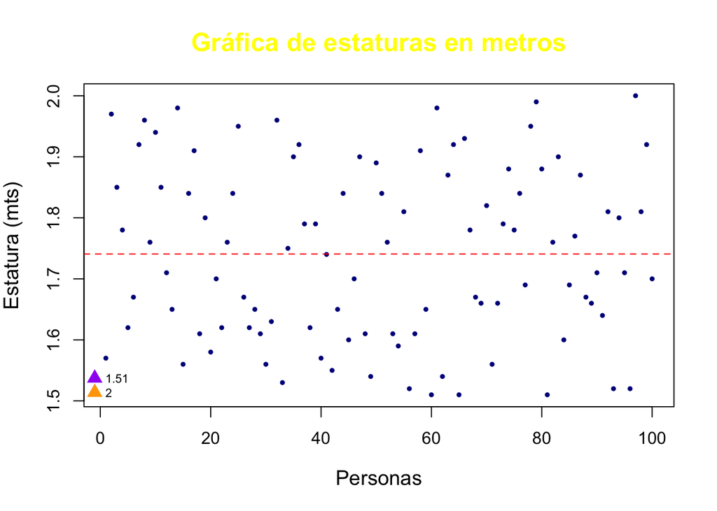

```r
plot(
  estatura,
  main = "Gráfica de estaturas en metros",
  xlab = "Personas",
  ylab = "Estatura (mts)",
  col = "darkblue",
  pch = 20,
  cex = 0.75,
  cex.main = 1.5,
  cex.lab = 1.2,
  col.main = "yellow")
legend(
  "bottomleft",                  # ubicación
  legend = c(mi_min,mi_max),    # etiquetas
  pch = 17,
  col=c("purple","orange"),
  pt.cex = 1.5,                # tamaño de los símbolos
  cex = 0.7,
  bty = "n"                    # sin borde en la caja
)
abline(h = x_media, col = "red", lwd = 1, lty = 2)
abline(h = Q2, col = "lightgreen", lwd = 1, lty = 3)
abline(h = mis_deciles, col = "lightgray", lty = 1.5)
points(which.min(kgs), min(kgs), col = "purple", pch = 17, cex = 1.5)
points(which.max(kgs), max(kgs), col = "orange", pch = 17, cex = 1.5)
```

Con la misma idea que la gráfica anterior, generemos un histograma de los mismos datos

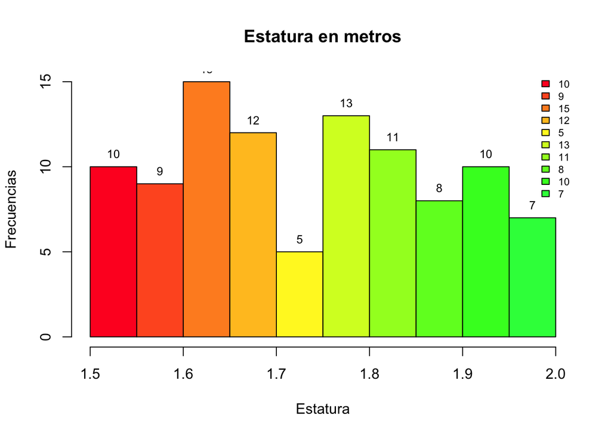

```r
nbreaks=8;
miscolores <- rainbow(25,0.85);
h <- hist(estatura, breaks = nbreaks, col= miscolores,
          main = 'Estatura en metros',
          xlab="Estatura",
          ylab="Frecuencias")
text(h$mids, h$counts, labels = h$counts, pos = 3, cex = 0.8,
     col = "black")
nl <- length(h$counts);
legend(
  "topright",                  # ubicación
  legend = h$counts,    # etiquetas
  fill = miscolores,
  col = miscolores,    # colores (uno por cada símbolo)
  pt.cex = 1.5,                # tamaño de los símbolos
  cex = 0.7,
  bty = "n"                    # sin borde en la caja
)
```

Mejoremos el gráfico agregando detalles, leyendas e información en la parte lateral de la gráfica

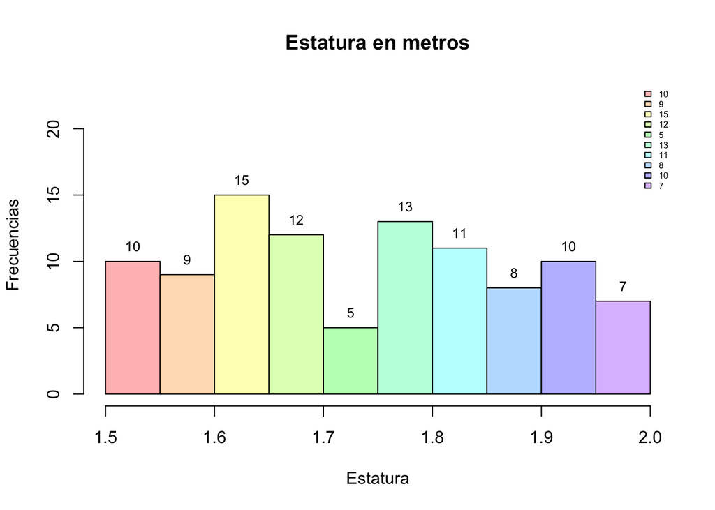

```r
##---- Mejora del grafico ----
miscolores <- rainbow(12,0.25);
h2 <- hist(estatura, breaks = nbreaks, col= miscolores,
          main = 'Estatura en metros',
          xlab="Estatura",
          ylab="Frecuencias",
          ylim=c(0,max(h$counts)*1.5))
text(h$mids, h$counts, labels = h$counts, pos = 3, cex = 0.8,
     col = "black")
nl <- length(h$counts);
legend(
  "topright",                  # ubicación
  legend = h$counts,    # etiquetas
  fill = miscolores,
  col = miscolores,    # colores (uno por cada símbolo)
  pt.cex = 1.5,                # tamaño de los símbolos
  cex = 0.5,
  bty = "n"                    # sin borde en la caja
)
```

```r
#---- Graficos de pastel ----
# Tus datos
nbreaks <- 10
intervalos <- cut(estatura, breaks = nbreaks); (intervalos)
```

```
##   [1] (1.56,1.61] (1.95,2]    (1.8,1.85]  (1.75,1.8]  (1.61,1.66] (1.66,1.71]
##   [7] (1.9,1.95]  (1.95,2]    (1.75,1.8]  (1.9,1.95]  (1.8,1.85]  (1.71,1.75]
##  [13] (1.61,1.66] (1.95,2]    (1.56,1.61] (1.8,1.85]  (1.9,1.95]  (1.61,1.66]
##  [19] (1.75,1.8]  (1.56,1.61] (1.66,1.71] (1.61,1.66] (1.75,1.8]  (1.8,1.85]
##  [25] (1.9,1.95]  (1.66,1.71] (1.61,1.66] (1.61,1.66] (1.61,1.66] (1.56,1.61]
##  [31] (1.61,1.66] (1.95,2]    (1.51,1.56] (1.71,1.75] (1.85,1.9]  (1.9,1.95]
##  [37] (1.75,1.8]  (1.61,1.66] (1.75,1.8]  (1.56,1.61] (1.71,1.75] (1.51,1.56]
##  [43] (1.61,1.66] (1.8,1.85]  (1.56,1.61] (1.66,1.71] (1.85,1.9]  (1.61,1.66]
##  [49] (1.51,1.56] (1.85,1.9]  (1.8,1.85]  (1.75,1.8]  (1.61,1.66] (1.56,1.61]
##  [55] (1.8,1.85]  (1.51,1.56] (1.61,1.66] (1.9,1.95]  (1.61,1.66] (1.51,1.56]
##  [61] (1.95,2]    (1.51,1.56] (1.85,1.9]  (1.9,1.95]  (1.51,1.56] (1.9,1.95]
##  [67] (1.75,1.8]  (1.66,1.71] (1.66,1.71] (1.8,1.85]  (1.56,1.61] (1.66,1.71]
##  [73] (1.75,1.8]  (1.85,1.9]  (1.75,1.8]  (1.8,1.85]  (1.66,1.71] (1.9,1.95]
##  [79] (1.95,2]    (1.85,1.9]  (1.51,1.56] (1.75,1.8]  (1.85,1.9]  (1.56,1.61]
##  [85] (1.66,1.71] (1.75,1.8]  (1.85,1.9]  (1.66,1.71] (1.66,1.71] (1.71,1.75]
##  [91] (1.61,1.66] (1.8,1.85]  (1.51,1.56] (1.75,1.8]  (1.71,1.75] (1.51,1.56]
##  [97] (1.95,2]    (1.8,1.85]  (1.9,1.95]  (1.66,1.71]
## 10 Levels: (1.51,1.56] (1.56,1.61] (1.61,1.66] (1.66,1.71] ... (1.95,2]
```

```r
tabla <- table(intervalos); (tabla)
```

```
## intervalos
## (1.51,1.56] (1.56,1.61] (1.61,1.66] (1.66,1.71] (1.71,1.75]  (1.75,1.8]
##          10           9          15          12           5          13
##  (1.8,1.85]  (1.85,1.9]  (1.9,1.95]    (1.95,2]
##          11           8          10           7
```

```r
porcentajes <- round(prop.table(tabla) * 100, 1); (porcentajes)
```

```
## intervalos
## (1.51,1.56] (1.56,1.61] (1.61,1.66] (1.66,1.71] (1.71,1.75]  (1.75,1.8]
##          10           9          15          12           5          13
##  (1.8,1.85]  (1.85,1.9]  (1.9,1.95]    (1.95,2]
##          11           8          10           7
```

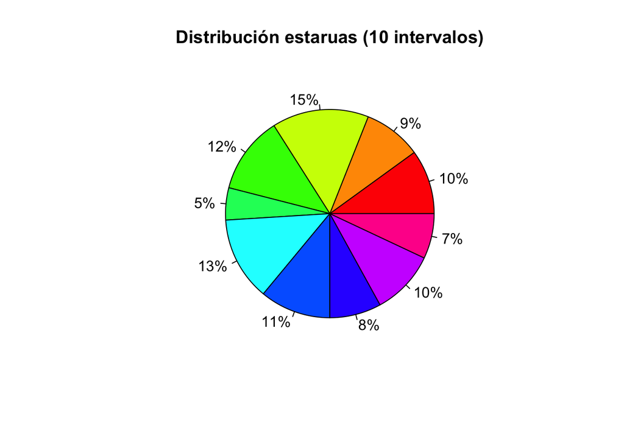

```r
pie(tabla,
    main = "Distribución estaruas (10 intervalos)",
    col = rainbow(length(tabla)),
    labels = paste0(porcentajes, "%"))
```